# Counting

Ho Ngoc Van

3/1/2021

**Question 1:** How many ways are there to permute the letters in the word MISSISSIPPI?

**Answer:** $\frac{11!}{1!4!4!2!}$

**Code:**

Small example

```r
library(randtests)
s <- c("M", "I", "M", "P")
unique(permut(s))
```

```
##       [,1] [,2] [,3] [,4]
##  [1,] "M"  "I"  "M"  "P"
##  [2,] "M"  "I"  "P"  "M"
##  [3,] "M"  "M"  "I"  "P"
##  [4,] "M"  "M"  "P"  "I"
##  [5,] "M"  "P"  "I"  "M"
##  [6,] "M"  "P"  "M"  "I"
##  [7,] "I"  "M"  "M"  "P"
##  [8,] "I"  "M"  "P"  "M"
##  [9,] "I"  "P"  "M"  "M"
## [10,] "P"  "M"  "I"  "M"
## [11,] "P"  "M"  "M"  "I"
## [12,] "P"  "I"  "M"  "M"
```

```r
factorial(length(s)) / prod(factorial(table(s)))
```

```
## [1] 12
```

Result

```r
s <- c("M", "I", "S", "S", "I", "S", "S", "I", "P", "P", "I")

factorial(length(s)) / prod(factorial(table(s)))
```

```
## [1] 34650
```

**Question 2:**

a.How many 7-digit phone numbers are possible, assuming that the first digit can’t be a 0 or a 1?

**Answer:** $8.10^6$

**Code:**

```r
8*10^6
```

```
## [1] 8e+06
```

b.Re-solve (a), expect now assume also that the phone number is not allowed to start with 911?

**Answer:** $7.9.9.10^4$

**Code:**

```r
7*9*9*10^4
```

```
## [1] 5670000
```

**Question 3:** Fred is planning to go out to dinner each night of a certain week, Monday through Friday, with each dinner being at one of his ten favorite restaurants.

a.How many possibilities are there for Fred’s schedule of dinner for that Monday through Friday. If Fred is not willing to eat at the same restaurant more than once?

**Answer:** $10.9.8.7.6$

**Code:**

```r
10*9*8*7*6
```

```
## [1] 30240
```

b.If Fred is willing to eat at the same restaurant more than once, but is not willing to eat at the same place twice in a row (or more)?

**Answer:** $10.9.9.9.9$

**Code:**

```r
10*9*9*9*9
```

```
## [1] 65610
```

**Question 4:** A *round-robin tournament* is being held with *n* tennis players; this means that every player will play against every other player exactly once

a.How many possible outcomes are there for the tournament (the outcome lists out who won and who lost for each game)?

**Answer:** $2^\binom n2$

**Code:**

```r
comb <- function(n, x) {
        factorial(n) / factorial(n-x) / factorial(x)
}

n <- 7
2^comb(n, 2)
```

```
## [1] 2097152
```

b.How many games are played in total?

**Answer:** $\binom n2$

**Code:**

```r
comb(n, 2)
```

```
## [1] 21
```

**Question 5:** A *knock-out tournament* is being held with $2^n$ tennis players. This means that for each round, the winners move on to the next round and the losers are eliminated, until only one person remains. For example, if initially there are $2^4=16$ players, then there are 8 games in the first round, then the 8 winners move on to round 2, then the 4 winners move on to round 3, then the 2 winners move on to round 4, the winner of which is declared the winner of the tournament. (There are various systems for determining who plays whom within a round, but these do not matter for this problem.)

a.How many rounds are there?

**Answer:** n

b.Count how many games in total are played, by adding up the numbers of games played in each round?

**Answer:** $\sum_{k=1}^{n}2^{k-1}=2^n-1$

**Code:**

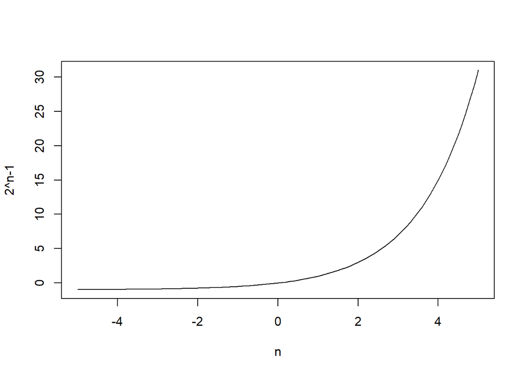

```r
curve(2^x-1, -5, 5, xlab = "n", ylab = "2^n-1")
```

c.Count how many games in total are played, this time by directly thinking about it without doing almost any calculation?

**Hint:** $\color{gray}{\text{How many players need to be eliminated?}}$

**Answer:** #players are eliminated = $2^n - 1$

**Question 6:** There are 20 people at a chess club on a certain day. They each find opponents and start playing. How many possibilities are there for how they are matched up, assuming that in each game it does matter who has the white pieces (in a chess game, one player has the white pieces and the other player has the black pieces)

**Answer:** $2\binom {20}2$

**Code:**

```r
comb <- function(n, x) {
        factorial(n) / factorial(n-x) / factorial(x)
}

2*comb(20, 2)
```

```
## [1] 380
```

**Question 7:** Two chess players, A and B, are going to play 7 games. Each game has three possible outcomes: a win for A (which is a loss for B), a draw (tie), and a loss for A (which is a win for B). A win is worth 1 point, a draw is worth 0.5 points, and a loss is worth 0 points.

a.How many possible outcomes for the individual games are there, such that overall player A ends up with 3 wins, 2 draws, and 2 losses?

**Answer:** $\binom 73 \binom 42 \binom 22$

**Code:**

```r
comb <- function(n, x) {
        factorial(n) / factorial(n-x) / factorial(x)
}

comb(7, 3) * comb(4, 2) * comb(2, 2)
```

```
## [1] 210
```

b.How many possible outcomes for the individual games are there, such that A ends up with 4 points and B ends up with 3 points?

**Answer:** #A_win = x, #A_draw = y, #A_loss = z

$$\begin{cases} x+y+z=7\\\\1x+0.5y+0z=4 \end{cases} \to \begin{cases} x-z=4\\\\2x+y=8\\\\1\le{x}\le4 \end{cases} \to \sum_{k-1}^{4}{\binom 7k \binom {7-k}{k-1}}$$

**Code:**

```r
sum(sapply(1:4, function(x) {comb(7, x)*comb(7-x, x-1)}))
```

```
## [1] 357
```

c.Now assume that they are playing a best-of-7 match, where the match will end when either player has 4 points or when 7 games have been played, whichever is first. For example, if after 6 games the score is 4 to 2 in favor of A, then A wins the match and they don’t play a 7th game. How many possible outcomes for the individual games are there, such that the match lasts for 7 games and A wins by a score of 4 to 3?

**Answer:** Two cases

*Case 1*: 3.5 - 2.5 after 6 games. 7th game draw

$$\begin{cases} x+y+z=6\\\\1x+0.5y+0z=3.5 \end{cases} \to \begin{cases} x-z=1\\\\2x+y=7\\\\1\le{x}\le3 \end{cases} \to \sum_{k=1}^{3}{\binom 6k\binom {6-k}{7-2k}\binom {k-1}{k-1}=126}$$

*Case 2*: 3-3 after 6 games, 7th game 7 win

$$\begin{cases} x+y+z=6\\\\1x+0.5y+0z=3 \end{cases} \to \begin{cases} x-z=0\\\\2x+y=6\\\\0\le{x}\le3 \end{cases} \to \sum_{k=0}^{3}{\binom 6k\binom {6-k}{6-2k}\binom kk=141}$$

**Code:**

```r
c1 <- sum(sapply(1:3, function(x) {comb(6, x)*comb(6-x, 7-2*x)*comb(x-1, x-1)}))
c2 <- sum(sapply(0:3, function(x) {comb(6, x)*comb(6-x, 6-2*x)*comb(x, x)}))

c1 + c2
```

```
## [1] 267
```

**Question 8:**

a.How many ways are there to split a dozen people into 3 teams, where one team has 2 people, and the other two teams have 5 people each?

**Answer:** $\frac{\binom {12}5 \binom 75 \binom 22}{2!}$

**Code:**

```r
comb <- function(n, x) {
        factorial(n) / factorial(n-x) / factorial(x)
}

comb(12, 5)*comb(7, 5)*comb(2, 2)/2
```

```
## [1] 8316
```

b.How many ways are there to split a dozen people into 3 teams, where each team has 4 people?

**Answer:** $\frac{\binom {12}4 \binom 84 \binom 44}{3!}$

**Code:**

```r
comb(12, 4) * comb(8, 4) * comb(4, 4)/(3*2*1)
```

```
## [1] 5775
```

**Question 9:**

a.How many paths are there from the point (0, 0) to the point (110, 110) in the plane such that each step either consists of going one unit up or one unit to the right?

**Answer:** $\binom {221}{110}$

**Code:**

```r
comb <- function(n, x) {
        factorial(n) / factorial(n-x) / factorial(x)
}

comb(221, 110)
```

```
## [1] Inf
```

Here, we know that the factorial of 221 is too big, we can’t calculate by using the factorial function. To solve this problem, we rewrite the comb function.

```r
comb <- function(n, k){
        prod((n-k+1):n/1:k)
}

comb(221, 110)
```

```
## [1] 1.802617e+65
```

b.How many paths are there from (0, 0) to (210, 221), where each step consists of going one unit up or one unit to the right, and the path has to go through (110, 111)?

**Answer:** $\binom {221}{110} \binom {200}{100}$

**Code:**

```r
comb(221, 110) * comb(200, 100)
```

```
## [1] 1.632243e+124
```

**Question 10:** To fulfill the requirements for a certain degree, a student can choose to take any 7 out of a list of 20 courses, with the constraint that at least 1 of the 7 courses must be a statistics course. Suppose that 5 of the 20 courses are statistics courses.

a.How many choices are there for which 7 courses to take?

**Answer:**

**Code:**

b.Explain intuitively why the answer to (a) is not $\binom 51 * \binom {19}6$?

**Answer:**

**Code:**

**Question 11:** Let A and B be sets with |A| = n, |B| = m.

a.How many functions are there from A to B (i.e., functions with domain A, assigning an element of B to each element of A)?

**Answer:**

**Code:**

b.How many one-to-one functions are there from A to B?

**Answer:**

**Code:**

**Question 12:** Four players, named A, B, C and D, are playing a card game. A standard, well-shuffled deck of cards is dealt to the players (so each player receives a 13-card hand).

a.How many possibilities are there for the hand that player A will get? (Within a hand, the order in which cards were received doesn’t matter)?

**Answer:**

**Code:**

b.How many possibilities are there overall for what hands everyone will get, assuming that it matters which player gets which hand, but not the order of cards within a hand?

**Answer:**

**Code:**

c.Explain intuitively why the answer to (b) is not the fourth power of the answer to a()

**Answer:**

**Code:**

**Hint:** $\color {gray}{\text{Bose-Einstein}}$

**Answer:**

**Code:**

**Question 14:** You are ordering two pizzas. A pizza can be small, medium, large, or extra large, with any combination of 8 possible toppings (getting no toppings is allowed, as is getting all 8). How many possibilities are there for your two pizzas?

**Answer:**

**Code:**